# Week 4 Homework: Global Gender Inequality Index, 2010 vs 2019

JingTian-2026

2026-11-08

## 1. Aim

This document reads the UNDP Gender Inequality Index (GII), joins it to a world countries spatial dataset, and calculates the change in gender inequality between 2010 and 2019.

A **negative** difference means inequality fell (improved) between 2010 and 2019. A **positive** difference means inequality rose.

## 2. Packages

```r
library(sf)          # read and handle spatial data
library(tidyverse)   # data wrangling (dplyr, readr, ...)
library(here)        # build file paths relative to the project
library(janitor)     # clean column names
library(countrycode) # convert country codes (ISO2 -> ISO3)
library(tmap)        # quick maps
```

## 3. Data

Two files are stored in the `data/` folder of this project:

- **Gender inequality data**: “All composite indices and components time series (1990-2023)” CSV from the UNDP Human Development Reports data centre (https://hdr.undp.org/data-center/documentation-and-downloads).
- **World countries**: a `.geojson` of country boundaries (e.g. *World Countries (Generalized)* from ArcGIS Hub, or the file provided on Moodle).

> Change the file names below if yours are different.

```r
# Gender inequality data (CSV). latin1 keeps names like "Côte d'Ivoire" readable.
hdr <- read_csv(here("data", "HDR25_Composite_indices_complete_time_series.csv"),
                locale = locale(encoding = "latin1"),
                na = c("", "NA", ".."))

# World spatial data (GeoJSON)
world <- st_read(here("data", "World_Countries_Generalized.geojson"))
```

Check what the data look like before joining:

```r
# Column names of the spatial data
names(world)
```

```
## [1] "FID"        "COUNTRY"    "ISO"        "COUNTRYAFF" "AFF_ISO"
## [6] "geometry"
```

```r
# Gender inequality columns all start with "gii_"
hdr %>%
  select(iso3, country, starts_with("gii_")) %>%
  head()
```

```
## # A tibble: 6 × 37
##   iso3  country       gii_rank_2023 gii_1990 gii_1991 gii_1992 gii_1993 gii_1994
##   <chr> <chr>                 <dbl>    <dbl>    <dbl>    <dbl>    <dbl>    <dbl>
## 1 AFG   Afghanistan             168       NA       NA       NA       NA       NA
## 2 ALB   Albania                  35       NA       NA       NA       NA       NA
## 3 DZA   Algeria                 114       NA       NA       NA       NA       NA
## 4 AND   Andorra                  NA       NA       NA       NA       NA       NA
## 5 AGO   Angola                  139       NA       NA       NA       NA       NA
## 6 ATG   Antigua and …            63       NA       NA       NA       NA       NA
## # ℹ 29 more variables: gii_1995 <dbl>, gii_1996 <dbl>, gii_1997 <dbl>,
## #   gii_1998 <dbl>, gii_1999 <dbl>, gii_2000 <dbl>, gii_2001 <dbl>,
## #   gii_2002 <dbl>, gii_2003 <dbl>, gii_2004 <dbl>, gii_2005 <dbl>,
## #   gii_2006 <dbl>, gii_2007 <dbl>, gii_2008 <dbl>, gii_2009 <dbl>,
## #   gii_2010 <dbl>, gii_2011 <dbl>, gii_2012 <dbl>, gii_2013 <dbl>,
## #   gii_2014 <dbl>, gii_2015 <dbl>, gii_2016 <dbl>, gii_2017 <dbl>,
## #   gii_2018 <dbl>, gii_2019 <dbl>, gii_2020 <dbl>, gii_2021 <dbl>, …
```

## 4. Wrangle the gender inequality data

Keep only the columns we need and calculate the difference.

```r
gii <- hdr %>%
  clean_names() %>%
  # keep country rows only (regional aggregates have iso3 starting with "ZZ")
  filter(!str_starts(iso3, "ZZ")) %>%
  select(iso3, undp_country = country, gii_2010, gii_2019) %>%
  mutate(gii_diff_2010_2019 = gii_2019 - gii_2010)

head(gii)
```

```
## # A tibble: 6 × 5
##   iso3  undp_country        gii_2010 gii_2019 gii_diff_2010_2019
##   <chr> <chr>                  <dbl>    <dbl>              <dbl>
## 1 AFG   Afghanistan            0.704    0.676            -0.0280
## 2 ALB   Albania                0.192    0.131            -0.061
## 3 DZA   Algeria                0.508    0.385            -0.123
## 4 AND   Andorra               NA       NA                NA
## 5 AGO   Angola                 0.556    0.536            -0.0200
## 6 ATG   Antigua and Barbuda   NA       NA                NA
```

## 5. Join to the spatial data

The world GeoJSON uses **2-letter** ISO codes (column `ISO`), while the UNDP data uses **3-letter** ISO codes (`iso3`). We use `countrycode` to create a matching 3-letter code before joining.

```r
world_gii <- world %>%
  clean_names() %>%
  mutate(iso3 = countrycode(iso, origin = "iso2c", destination = "iso3c")) %>%
  left_join(gii, by = "iso3")

# How many countries did not get a match?
sum(is.na(world_gii$gii_diff_2010_2019))
```

```
## [1] 94
```

## 6. Results

```r
world_gii %>%
  st_drop_geometry() %>%
  filter(!is.na(gii_diff_2010_2019)) %>%
  arrange(gii_diff_2010_2019) %>%
  select(undp_country, iso3, gii_2010, gii_2019, gii_diff_2010_2019) %>%
  head(10)
```

```
##            undp_country iso3 gii_2010 gii_2019 gii_diff_2010_2019
## 1                 Qatar  QAT    0.663    0.162             -0.501
## 2          Saudi Arabia  SAU    0.754    0.283             -0.471
## 3                 Tonga  TON    0.767    0.450             -0.317
## 4                Bhutan  BTN    0.442    0.265             -0.177
## 5                 Chile  CHL    0.350    0.195             -0.155
## 6               Türkiye  TUR    0.411    0.270             -0.141
## 7               Armenia  ARM    0.352    0.216             -0.136
## 8               Georgia  GEO    0.430    0.296             -0.134
## 9                 Egypt  EGY    0.552    0.424             -0.128
## 10 United Arab Emirates  ARE    0.165    0.039             -0.126
```

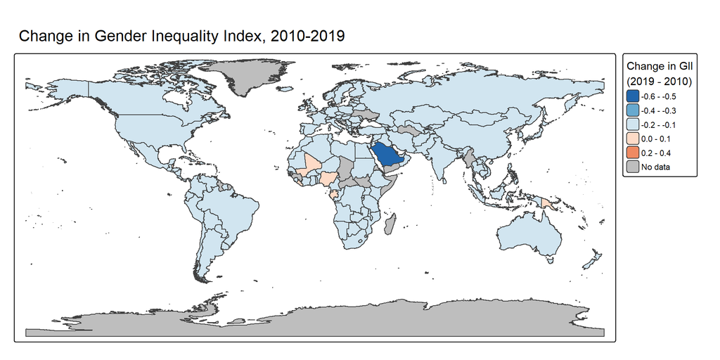

```r
tmap_mode("plot")

tm_shape(world_gii) +
  tm_polygons("gii_diff_2010_2019",
              palette = "-RdBu",   # blue = inequality fell, red = rose
              midpoint = 0,
              title = "Change in GII\n(2019 - 2010)",
              textNA = "No data") +
  tm_layout(main.title = "Change in Gender Inequality Index, 2010-2019",
            legend.outside = TRUE)
```

## 7. Save the output

```r
dir.create(here("output"), showWarnings = FALSE)
st_write(world_gii, here("output", "world_gii_2010_2019.gpkg"),
         delete_dsn = TRUE)
```

```
## Deleting source `C:/Users/a1818/UCLcasa/casa0005-week4-genderinequality/output/world_gii_2010_2019.gpkg' using driver `GPKG'
## Writing layer `world_gii_2010_2019' to data source
##   `C:/Users/a1818/UCLcasa/casa0005-week4-genderinequality/output/world_gii_2010_2019.gpkg' using driver `GPKG'
## Writing 251 features with 10 fields and geometry type Multi Polygon.
```

## 8. Reproducibility

The raw data are not pushed to GitHub (see `.gitignore`). To reproduce this analysis, download the two files listed in Section 3 into a `data/` folder and knit this document.